# Lab 3: Analisi de Correspondencies i Normal multivariant

Álvaro Ribot

## Exercici 1: Anticonceptius a indonesia

```r
library("FactoMineR")
library("factoextra")
library("ca")
```

### a)

```r
X <- read.table("http://www-eio.upc.es/~jan/Data/MVA/cmc.dat", header = T, sep = ",")
head(X)
```

|  | Age | WifeEduc | HusbEduc | Childs | Rel | Work | Occup | Standard | Media | Method |
| --- | --- | --- | --- | --- | --- | --- | --- | --- | --- | --- |
| 1 | 24 | 2 | 3 | 3 | 1 | 1 | 2 | 3 | 0 | 1 |
| 2 | 45 | 1 | 3 | 10 | 1 | 1 | 3 | 4 | 0 | 1 |
| 3 | 43 | 2 | 3 | 7 | 1 | 1 | 3 | 4 | 0 | 1 |
| 4 | 42 | 3 | 2 | 9 | 1 | 1 | 3 | 3 | 0 | 1 |
| 5 | 36 | 3 | 3 | 8 | 1 | 1 | 3 | 2 | 0 | 1 |
| 6 | 19 | 4 | 4 | 0 | 1 | 1 | 3 | 3 | 0 | 1 |

```r
for (i in 1:ncol(X)) {
  print(range(X[,i]))
}
```

```
[1] 16 49
[1] 1 4
[1] 1 4
[1]  0 16
[1] 0 1
[1] 0 1
[1] 1 4
[1] 1 4
[1] 0 1
[1] 1 3
```

Podem observar que el rang dels valors que prenen les variables categoriques coinicideix amb el de la seva codificacio. Per tant, podem concloure que no hi ha dades mancants.

### b)

```r
X$Method <- factor(X$Method, levels = c(1, 2, 3), labels = c("none", "long-term", "mid-term"))
X$WifeEduc <- factor(X$WifeEduc, levels = c(1, 2, 3, 4), labels = c("low", "prim", "mid", "high"))
```

### c)

```r
(taula <- table(X$Method, X$WifeEduc))
```

```
            low prim mid high
  none      103  176 175  175
  long-term   9   37  80  207
  mid-term   40  121 155  195
```

### d)

```r
chisq.test(taula)
```

```
    Pearson's Chi-squared test

data:  taula
X-squared = 140.46, df = 6, p-value < 2.2e-16
```

L’estadistic de prova pren valor $140.46$ i el p-valor es mes petit que $2.2e-16$. Per tant, podem concluir que hi ha associacio entre les variables (rebutgem la hipotessi nul·la que assumeix independència)

### e)

```r
out <- ca(taula)
(r <- out$rowmass)
```

```
[1] 0.4270197 0.2260692 0.3469111
```

```r
(c <- out$colmass)
```

```
[1] 0.1031908 0.2267481 0.2783435 0.3917176
```

Podem veure els pesos de *Method* i de *WifeEduc*, respectivament. Per tant, el métode conceptiu més utilitzat es “none”.

### f)

Es mostren les matrius de perfils fila i columna, respectivament.

```r
P <- as.matrix(taula)
P <- P/sum(P) # matriu de probabilitats
(R <- diag(1/r)%*%P)
```

```
              low      prim       mid      high
  [1,] 0.16375199 0.2798092 0.2782194 0.2782194
  [2,] 0.02702703 0.1111111 0.2402402 0.6216216
  [3,] 0.07827789 0.2367906 0.3033268 0.3816047
```

```r
(C <- diag(1/c)%*%t(P))
```

```
            none  long-term  mid-term
  [1,] 0.6776316 0.05921053 0.2631579
  [2,] 0.5269461 0.11077844 0.3622754
  [3,] 0.4268293 0.19512195 0.3780488
  [4,] 0.3032929 0.35875217 0.3379549
```

### g) **Mirar que es perfil marginal**

### h)

```r
summary(resultats)
```

```
Principal inertias (eigenvalues):

 dim    value      %   cum%   scree plot
 1      0.090755  95.2  95.2  ************************
 2      0.004600   4.8 100.0  *
        -------- -----
 Total: 0.095356 100.0


Rows:
    name   mass  qlt  inr    k=1 cor ctr    k=2 cor ctr
1 | none |  427 1000  362 | -280 973 370 |   47  27 203 |
2 | lngt |  226 1000  605 |  502 988 629 |   54  12 145 |
3 | mdtr |  347 1000   33 |   18  36   1 |  -93 964 652 |

Columns:
    name   mass  qlt  inr    k=1 cor ctr    k=2 cor ctr
1 |  low |  103 1000  314 | -517 919 303 |  154  81 531 |
2 | prim |  227 1000  197 | -284 976 202 |  -45  24  98 |
3 |  mid |  278 1000   21 |  -50 350   8 |  -68 650 277 |
4 | high |  392 1000  468 |  336 990 487 |   33  10  95 |
```

Existeixen dues dimensions, però observem que amb una dimensió ja obtenim el $95.2\%$. Per tant, podem representar adequadament la taula de contingencia amb una dimensio.

### i)

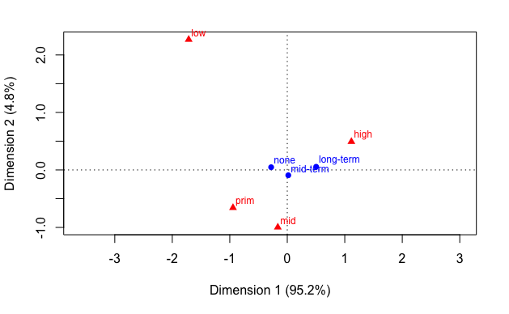

### k)

```r
X$Age <- as.factor(cut(X$Age, breaks = 4))
table(X$Age)
```

```
  (16,24.2] (24.2,32.5] (32.5,40.8]   (40.8,49]
        276         504         387         306
```

### l)

```r
table(X$AgeRel)/nrow(X)
```

```
  (16,24.2].0 (24.2,32.5].0 (32.5,40.8].0   (40.8,49].0   (16,24.2].1
  0.009504413   0.042090971   0.060420910   0.037338764   0.177868296
(24.2,32.5].1 (32.5,40.8].1   (40.8,49].1
  0.300067889   0.202308215   0.170400543
```

### m)

```r
(taula2 <- table(X$Method, X$AgeRel))
```

```
            (16,24.2].0 (24.2,32.5].0 (32.5,40.8].0 (40.8,49].0 (16,24.2].1
  none                5            22            27          21         121
  long-term           2            18            32          24          35
  mid-term            7            22            30          10         106

            (24.2,32.5].1 (32.5,40.8].1 (40.8,49].1
  none                170           109         154
  long-term            77            85          60
  mid-term            195           104          37
```

### n)

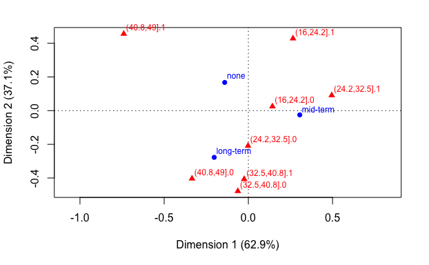

En aquest cas observem que son necessaries dues dimensions per fer una bona representació de la taula de contingencia, ja que amb una dimensio nomes representariem be un $62.9\%$.

En general, les dones que practiquen la religio islamica tendeixen a utilitzar menys metodes anticonceptius que les no creients. Tambe podem notar que les dones joves tendeixen a utilitzar metodes anticonceptius de curt termini i a mesura que es fan gran utilitzen els de llarg termini.

### o)

```r
summary(acmult <- mjca(tmult, lambda = "indicator"))
```

```
Principal inertias (eigenvalues):

 dim    value      %   cum%   scree plot
 1      0.490556  12.3  12.3  ***
 2      0.456773  11.4  23.7  ***
 3      0.357164   8.9  32.6  **
 4      0.345038   8.6  41.2  **
 5      0.334913   8.4  49.6  **
 6      0.333333   8.3  57.9  **
 7      0.333333   8.3  66.3  **
 8      0.321610   8.0  74.3  **
 9      0.299496   7.5  81.8  **
 10     0.279349   7.0  88.8  **
 11     0.232542   5.8  94.6  *
 12     0.215894   5.4 100.0  *
```

[output cut: 21 more lines]

L’anàlisi té $12$ dimensions, i la inercia de la matriu d’indicadors es $4$. En dues dimensions la bondat de l’ajust és del $23.7\%$.

### p) **falta interpretar**

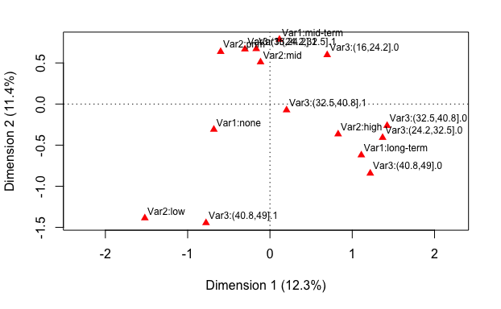

### q)

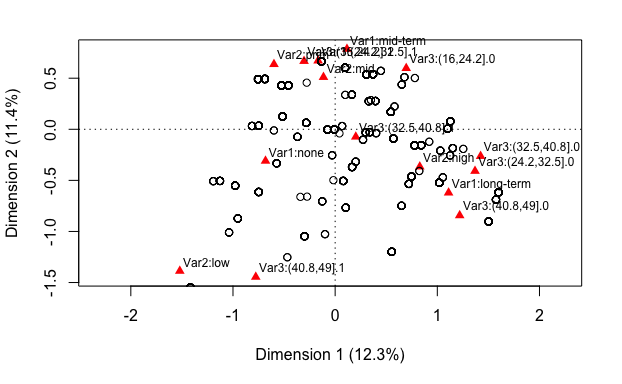

```r
plot(acmult)
points(acmult$rowpcoord)
```

### r)

```r
summary(B <- mjca(tmult, lambda = "Burt"))
```

```
Principal inertias (eigenvalues):

 dim    value      %   cum%   scree plot
 1      0.240645  17.2  17.2  ****
 2      0.208641  14.9  32.0  ****
 3      0.127566   9.1  41.1  **
 4      0.119051   8.5  49.6  **
 5      0.112167   8.0  57.6  **
 6      0.111111   7.9  65.6  **
 7      0.111111   7.9  73.5  **
 8      0.103433   7.4  80.9  **
 9      0.089698   6.4  87.3  **
 10     0.078036   5.6  92.8  *
 11     0.054076   3.9  96.7  *
 12     0.046610   3.3 100.0  *
```

[output cut: 21 more lines]

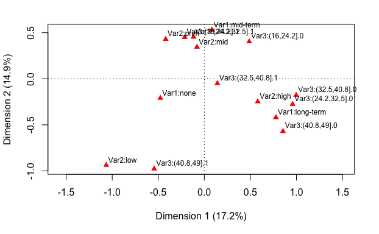

```r
plot(B)
```

S’assembla molt a l’analisi utilitzant la matriu d’indicadors. El plot sembla el mateix pero escalat. Tot i amb això, amb dues dimension s’obté una bondat d’ajust del $32.0\%$, mentre que amb la matriu d’indicadors aconseguiem un $23.7\%$. Podem veure també aquesta diferència comparant els screeplots dels summaries dels dos anàlisis.